# Semi-Supervised Classification with Graph Convolutional Networks

### Thomas Kipf & Max Welling (ICLR 2017)

**Leonardo Lavagna**  
**09/07/25**

## Motivation & Problem Statement

**Goal:** Predict node classes in a graph using limited labeled data.

- Graph = structured domain (e.g., citation, social, biological)
- Each node: feature vector
- Edges: encode relationships

**Challenge:**

- Traditional ML assumes regular input (grids, sequences)
- Graphs are irregular: variable degree, no canonical order

*Example:* Classify papers in a citation graph with only 5% labeled.

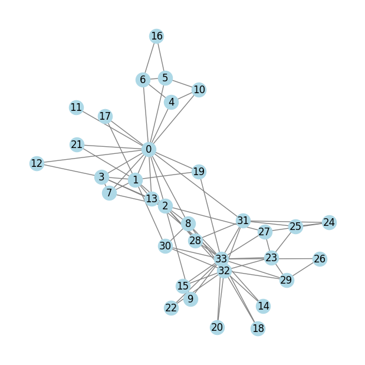

```python
#...
```

## What GCNs Solve

GCNs extend neural networks to graphs.

**Why MLPs fail:** Ignore edges (structure)  
**Why label propagation fails:** Relies only on topology; lacks learnable transformation

GCNs combine:

- Node features (like MLPs)
- Graph structure (like LP)
- Learn how to propagate and transform features over graph topology.

## Spectral Graph Convolutions

**Graph Fourier Transform:**

$$ L = I - D^{-1/2} A D^{-1/2} $$
with eigenbasis
$$ L = U \Lambda U^\top $$

**Convolution on a graph:**

$$ g_\theta * x = U g_\theta(\Lambda) U^\top x $$

**Why this works:**

- $U^\top x$: Graph Fourier transform
- $g_\theta(\Lambda)$: Learnable spectral filter

Problem: Computing $U$ is expensive $O(N^3)$

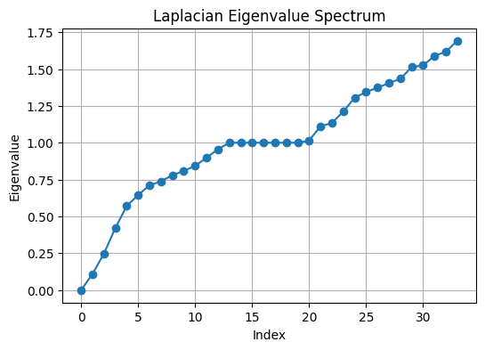

```python
#...
```

## Chebyshev Polynomial Approximation

To avoid costly eigendecomposition:

$$ g_\theta * x \approx \sum_{k=0}^K \theta_k T_k(\tilde{L}) x $$

Where:

- $T_k$: Chebyshev polynomial of degree $k$
- $\tilde{L} = \frac{2}{\lambda_{\max}} L - I$

**Advantages:**

- Localized filters ($K$-hop neighborhood)
- Efficient computation: $O(K|E|)

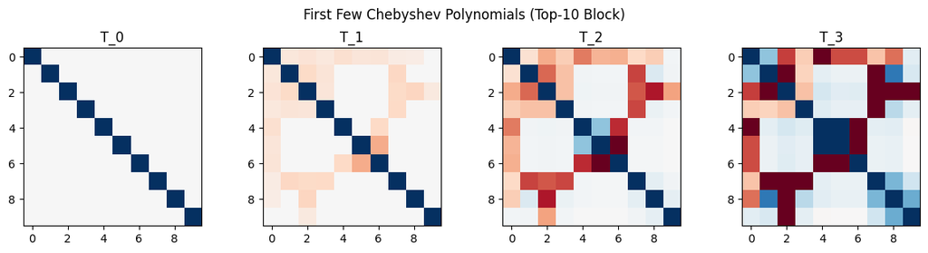

```python
# ...
```

## First-Order Approximation & GCN Layer

Set $K = 1$, we get:

$$ g_\theta * x \approx \theta (I + D^{-1/2} A D^{-1/2}) x $$

Numerical instability: eigenvalues up to 2 → gradient explosion

**Fix: Renormalization trick**

$$ \tilde{A} = A + I $$ $$ \hat{A} = \tilde{D}^{-1/2} \tilde{A} \tilde{D}^{-1/2} $$

**GCN Layer**:

$$ H^{(l+1)} = \sigma(\hat{A} H^{(l)} W^{(l)}) $$

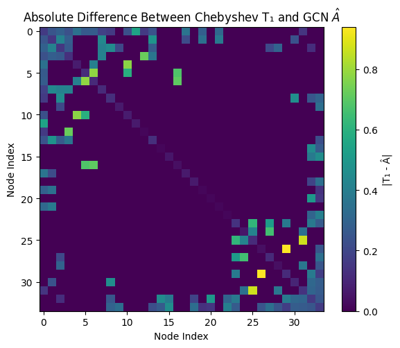

```python
#...
```

## Full GCN Forward Pass

**Two-layer GCN:**

$$ Z = \text{softmax}(\hat{A} \cdot \text{ReLU}(\hat{A} X W^{(0)}) W^{(1)}) $$

- $W^{(0)}$: input → hidden
- $W^{(1)}$: hidden → output
- $\hat{A}$: normalized adjacency with self-loops

Each layer:  
**Aggregate → Transform → Nonlinear Activation**

## Why GCNs Work (Graph Signal Processing View)

### Graph as signal domain:

- Each feature dimension is a signal over the graph

### GCNs ≈ trainable low-pass filters:

- Smooth features across edges (homophily)
- Suppress noise, preserve global structure

### GCN = message passing + transformation:

- $\hat{A}$: Aggregation (graph filtering)
- $W^{(l)}$: Learnable transformation

Stacking layers:

- Expands receptive field ($k$-hop)
- Builds hierarchical representations

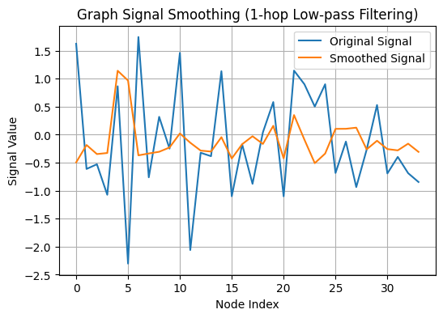

```python
#...
```

## GCN and Weisfeiler-Lehman Test

### Weisfeiler-Lehman (WL) Test:

$$ h_i^{(l+1)} = \text{hash}(h_i^{(l)}, \{ h_j^{(l)} : j \in \mathcal{N}(i) \}) $$

### GCN Analogy:

$$ h_i^{(l+1)} = \sigma\left( \sum_{j \in \mathcal{N}(i)} \frac{1}{\sqrt{d_i d_j}} h_j^{(l)} W^{(l)} \right) $$

**Why this matters:**

- Aggregates and transforms neighborhood info
- Differentiable, trainable generalization of WL
- Strong theoretical foundation for expressiveness

## Node Classification Results

**Datasets:** Cora, Citeseer, Pubmed

| Model | Cora | Citeseer | Pubmed |
| --- | --- | --- | --- |
| MLP | 55.1 | 46.5 | 71.4 |
| Planetoid | 75.7 | 64.7 | 77.2 |
| **GCN** | **81.5** | **70.3** | **79.0** |

Combines structure and features  
Outperforms static embeddings like DeepWalk

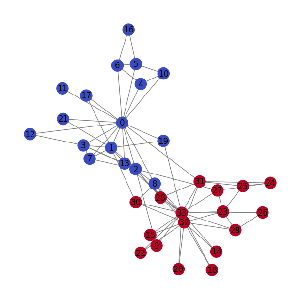

```python
# ...
```

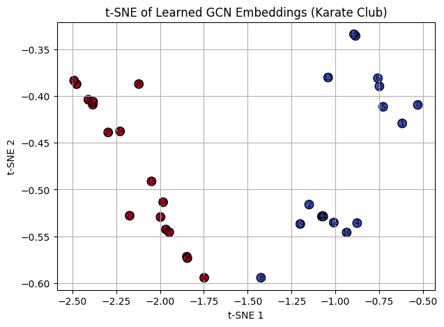

```python
#...
```

## Conclusion

✅ GCNs efficiently extend CNNs to graphs  
✅ Grounded in spectral graph theory  
✅ Learn to smooth and transform features via structure  
✅ Strong performance with few labels  
✅ Foundation of many modern GNNs

## Thank You

*Paper: Kipf & Welling, ICLR 2017*  
📎 https://tkipf.github.io/graph-convolutional-networks